# 사건 파일 #아구스 사망사건

Author

JW&SW

## 🕵️ Stage4 ‘탄지료 폐기물 수입’ 업체

**현장 조사 기록:**

- 이름: 아구스
- 직업: 석회석 가마 근로자
- 특징:
- 가족의 증언에 따르면 기침이 잦았음, 동료가 병원에 방문할 것을 권유하였으나 ’피곤해서 그런 것’이라며 넘겼다고 함.
- 자와자와 마을의 공기는 매우 탁함.
- 아구스씨의 가마 공장 창고에는 쓰레기가 가득함.
- **NEW**🔎 자와자와 마을에서는 쓰레기를 태워서 공장을 가동함.
- **NEW**🔎 마을 사람들이 쓰레기를 사는 업체가 있음.

### 🏭 **쓰레기 수입 업체**

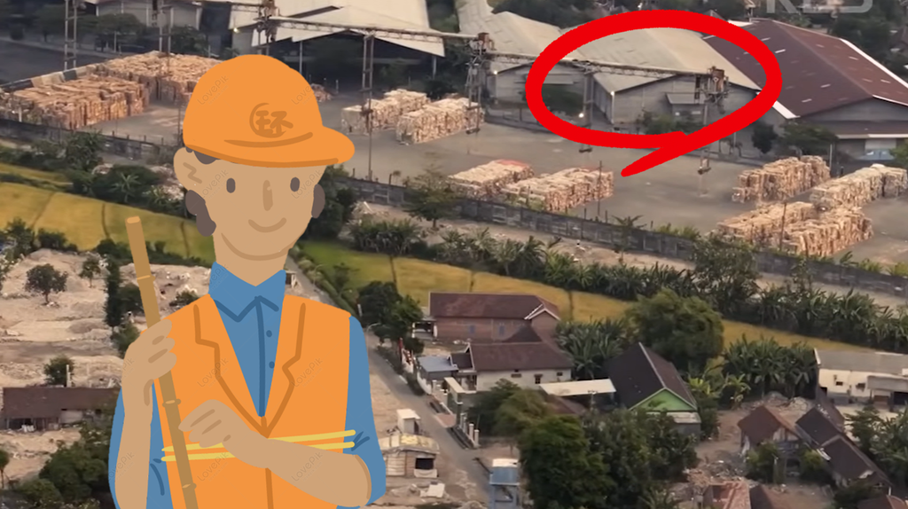

“당신이 마을 사람들에게 쓰레기를 파는 사람인가요?”

업체 사장: “네, 그런 셈이죠.”

“아니, 왜 사람들에게 쓰레기를 파는 거죠?”

“이 많은 쓰레기는 대체 어디서 난 거구요?”

업체 사장: “어디서 나긴…다 해외에서 수입한 겁니다.”

“왜 쓰레기를 수입하시는 거죠? 이건 말 그대로 쓰레기잖아요!”

업체 사장: “사실은…선진국에서 쓰레기를 돈 주고 인도네시아로 보내는 겁니다. 선진국에는 쓰레기를 처리할 곳도 없고, 비용도 많이 들거든요. 그런데 여기로 보내버리면 돈이 적게 드니까요…”

“쓰레기를 수출하는 건 불법으로 알고 있는데요?”

업체 사장: “그렇죠…하지만 폐지 거래는 불법이 아니기 때문에 폐지로 속여서 보내는 거죠.”

“그럼 혹시 어느 국가에서 쓰레기를 보내는지 알 수 있을까요?”

업체 사장: “그건 비밀유지조약에 따라 비밀입니다. 말씀드릴 수 없어요.”

“아니 그럴수가…”

어쩔 수 없나…사장이 없는 사이에 몰래 서류를 찾아봐야겠어!

(잠시 후 새벽🌙)

### 🔐**금고**

잠입 성공이군. 저기 금고 같은게 있는데?

이 안에 왠지 중요한 문서가 있을 것 같아.

금고를 열어보자!

### ❓ 문제

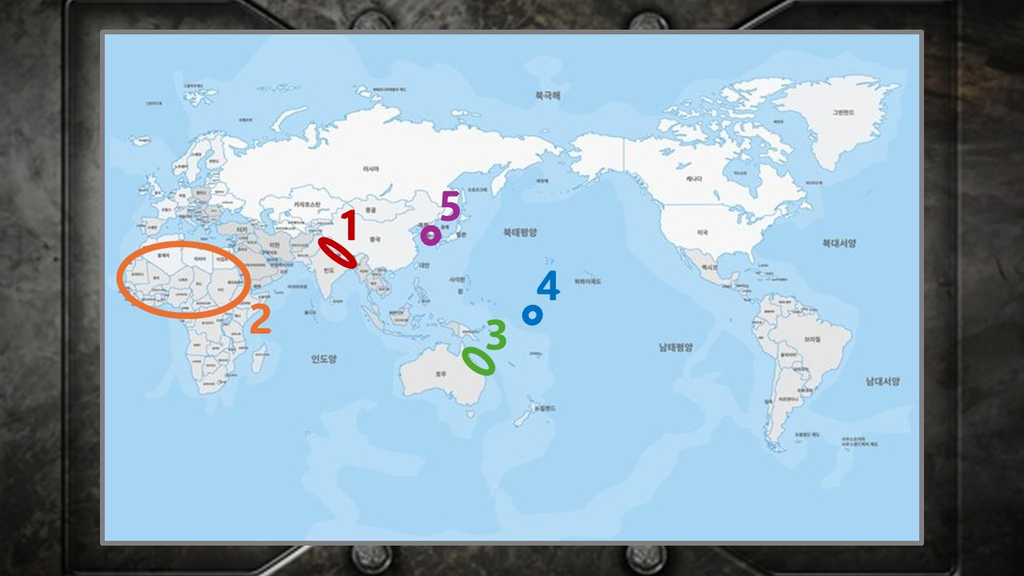

**다음 항목을 지도의 번호 순서대로 끌어놓자(단, 순서의 배열방향은 오른쪽이다):**

집중호우

사막화

해수면 상승

빙하 감소

산호초 백화현상